# Test

Bongseong Kim

2020-10-12

#### Grow a forest

```r
( Y.forest = regression_forest(X, Y, clusters = school.id, equalize.cluster.weights = TRUE) )
```

```
## GRF forest object of type regression_forest
## Number of trees: 2000
## Number of training samples: 10391
## Variable importance:
##     1     2     3     4     5     6     7     8     9    10    11    12    13
## 0.711 0.029 0.015 0.062 0.021 0.031 0.026 0.050 0.003 0.006 0.000 0.011 0.003
##    14    15    16    17    18    19    20    21    22    23    24    25    26
## 0.000 0.000 0.000 0.000 0.000 0.000 0.001 0.000 0.003 0.001 0.002 0.008 0.003
##    27    28
## 0.006 0.006
```

```r
Y.hat = predict(Y.forest)$predictions
```

```r
( W.forest = regression_forest(X, W, clusters = school.id, equalize.cluster.weights = TRUE) )
```

```
## GRF forest object of type regression_forest
## Number of trees: 2000
## Number of training samples: 10391
## Variable importance:
##     1     2     3     4     5     6     7     8     9    10    11    12    13
## 0.236 0.048 0.057 0.134 0.090 0.092 0.088 0.095 0.020 0.024 0.001 0.030 0.004
##    14    15    16    17    18    19    20    21    22    23    24    25    26
## 0.000 0.000 0.001 0.000 0.001 0.001 0.005 0.001 0.017 0.003 0.006 0.011 0.013
##    27    28
## 0.011 0.011
```

```r
W.hat = predict(W.forest)$predictions
```

W.hat은 Propensity score.

```r
cf.raw = causal_forest(X, Y, W,
                       Y.hat = Y.hat, W.hat = W.hat,
                       clusters = school.id,
                       equalize.cluster.weights = TRUE)
varimp = variable_importance(cf.raw)
selected.idx = which(varimp > mean(varimp))
```

전체 covariate을 포함한 RF를 구축한 뒤 variable importance가 전체 평균 보다 높은 변수만 남김.

#### Result

##### with Propensity score & with Cluster

```r
( cf = causal_forest(X[,selected.idx], Y, W,
                   Y.hat = Y.hat, W.hat = W.hat,
                   clusters = school.id,
                   equalize.cluster.weights = TRUE,
                   tune.parameters = "all") )
```

```
## GRF forest object of type causal_forest
## Number of trees: 2000
## Number of training samples: 10391
## Variable importance:
##     1     2     3     4     5     6     7     8     9
## 0.125 0.043 0.041 0.154 0.141 0.147 0.152 0.143 0.052
```

```r
ATE = average_treatment_effect(cf)
( ATE.yy = paste("95% CI for the ATE:", round(ATE[1], 3),
      "+/-", round(qnorm(0.975) * ATE[2], 3)) )
```

```
## [1] "95% CI for the ATE: 0.248 +/- 0.04"
```

##### with Propensity score & without Cluster

```r
cf.noclust = causal_forest(X[,selected.idx], Y, W,
                           Y.hat = Y.hat, W.hat = W.hat,
                           tune.parameters = "all")
ATE.noclust = average_treatment_effect(cf.noclust)
( ATE.yn = paste("95% CI for the ATE:", round(ATE.noclust[1], 3),
      "+/-", round(qnorm(0.975) * ATE.noclust[2], 3)) )
```

```
## [1] "95% CI for the ATE: 0.254 +/- 0.022"
```

##### without propensity score / with cluster

```r
cf.noprop = causal_forest(X[,selected.idx], Y, W,
                          Y.hat = Y.hat, W.hat = mean(W),
                          tune.parameters = "all",
                          equalize.cluster.weights = TRUE,
                          clusters = school.id)
ATE.noprop = average_treatment_effect(cf.noprop)
( ATE.ny = paste("95% CI for the ATE:", round(ATE.noprop[1], 3),
      "+/-", round(qnorm(0.975) * ATE.noprop[2], 3)) )
```

```
## [1] "95% CI for the ATE: 0.254 +/- 0.041"
```

##### without propensity score / without cluster

```r
cf.nono = causal_forest(X[,selected.idx], Y, W,
                          Y.hat = Y.hat, W.hat = mean(W),
                          tune.parameters = "all")
ATE.nono = average_treatment_effect(cf.nono)
( ATE.nn = paste("95% CI for the ATE:", round(ATE.nono[1], 3),
      "+/-", round(qnorm(0.975) * ATE.nono[2], 3)) )
```

```
## [1] "95% CI for the ATE: 0.258 +/- 0.022"
```

##### with Propensity score & with Cluster (Logistic ver.)

```r
logi = cbind.data.frame(W, X)
logi.res = glm(factor(W) ~ ., data = logi, family = binomial)
W.logi = logi.res$fitted.values
( cf.logi = causal_forest(X[,selected.idx], Y, W,
                   Y.hat = Y.hat, W.hat = W.logi,
                   clusters = school.id,
                   equalize.cluster.weights = TRUE,
                   tune.parameters = "all") )
```

```
## GRF forest object of type causal_forest
## Number of trees: 2000
## Number of training samples: 10391
## Variable importance:
##     1     2     3     4     5     6     7     8     9
## 0.115 0.042 0.039 0.173 0.139 0.136 0.152 0.158 0.047
```

```r
ATE.logi = average_treatment_effect(cf.logi)
( ATE.logistic = paste("95% CI for the ATE:", round(ATE.logi[1], 3),
      "+/-", round(qnorm(0.975) * ATE.logi[2], 3)) )
```

```
## [1] "95% CI for the ATE: 0.237 +/- 0.042"
```

Regression forest를 이용하여 Propensity score를 추정할 때 Cluster를 고려하였으나, Logistic은 그렇지 않았다는 차이가 있음.

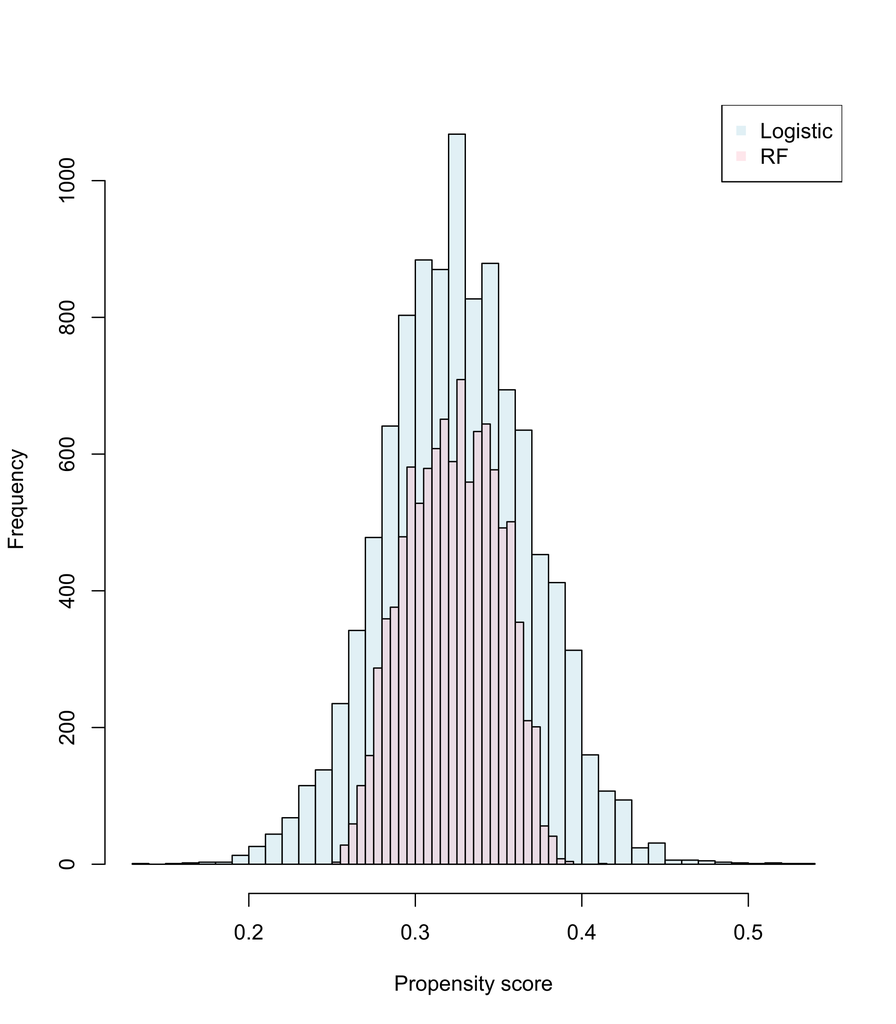

##### Standard regression model

```r
reg <- cbind.data.frame(Y, W, X[,selected.idx])
lm.result <- lm(Y ~ W + ., data = reg)
out <- summary(lm.result)
out$coefficients["W", 1:2]
```

```
##   Estimate Std. Error
## 0.25742514 0.01148065
```

```r
( ATE.lm = paste("95% CI for the ATE:", round(out$coefficients["W",1], 3),
                       "+/-", round(out$coefficients["W", 2], 3)) )
```

```
## [1] "95% CI for the ATE: 0.257 +/- 0.011"
```

##### Mixed regression model - 절편, 기울기

```r
mix <- cbind.data.frame(school.id, Y, W, X[,selected.idx])
mix.result <- lmer(Y ~ W + (1 + W | school.id) + ., data = mix)
out <- summary(mix.result)
out$coefficients["W", 1:2]
```

```
##   Estimate Std. Error
## 0.24663975 0.01828458
```

```r
( ATE.mix = paste("95% CI for the ATE:", round(out$coefficients["W",1], 3),
                 "+/-", round(out$coefficients["W", 2], 3)) )
```

```
## [1] "95% CI for the ATE: 0.247 +/- 0.018"
```

#### Summary

CRF, with ps / with cluster :  
95% CI for the ATE: 0.248 +/- 0.04

CRF, with ps / without cluster :  
95% CI for the ATE: 0.254 +/- 0.022

CRF, without ps / with cluster :  
95% CI for the ATE: 0.254 +/- 0.041

CRF, without ps / without cluster :  
95% CI for the ATE: 0.258 +/- 0.022

CRF, using logistic ps / with cluster :  
95% CI for the ATE: 0.237 +/- 0.042